# Experimentos TFM

## Experimento 4.5

Quiero ver qué pasa cuando añado un grupo falso con el mismo número de variables que el resto. En este caso la correlación es 0.9. Los datos los genero con:

$\theta = 1 + \beta_1X_1 + \beta_2X_2+ \beta_3X_3$, $\pi=\frac{e^{\theta}}{1 + e^{\theta}}$ e $Y\sim Ber(\pi)$.

Los coeficientes de los grupos los genero con una normal de media 0.5 y desviación típica 0.1, 0.15, 0.2, respectivamente

Como en 4.0 con una correlación de 0.9, pero añadiendo un cuarto grupo falso con el mismo número de variables que los grupos que generan los datos.

### Grupos

En general:

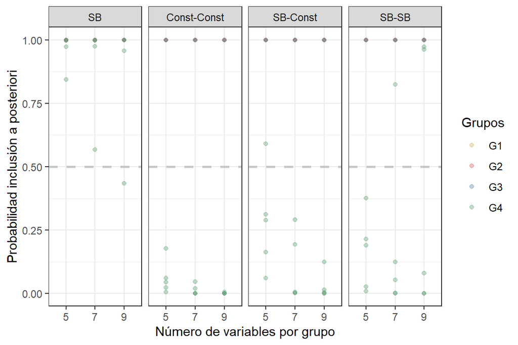

En función del número de variables:

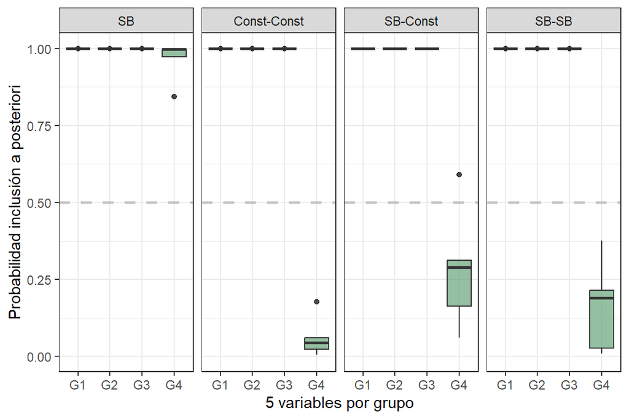

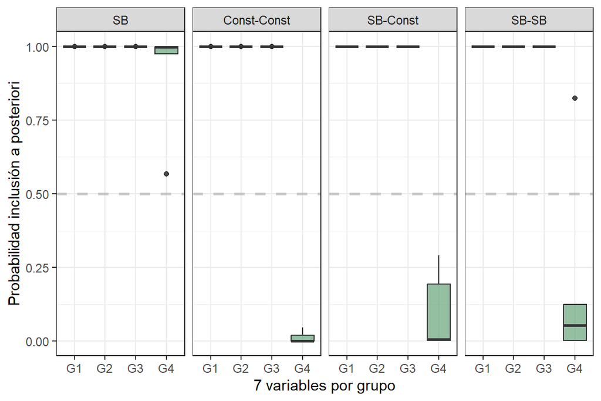

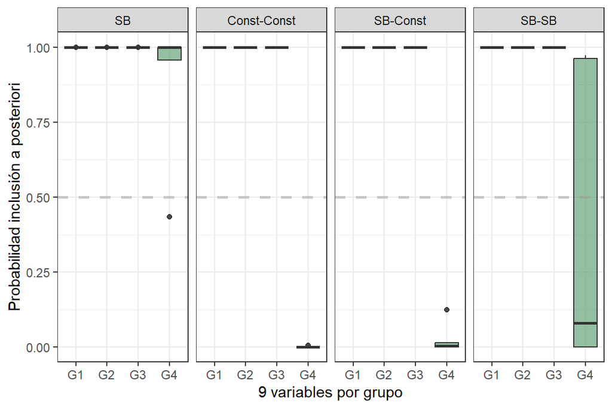

Porcentaje de grupos incorrectamente seleccionados:

Porcentaje de grupos incorrectamente seleccionados con SB.

|  | G4 |
| --- | --- |
| Num vars =5 | 100% |
| Num vars =7 | 100% |
| Num vars =9 | 80% |

Porcentaje de grupos incorrectamente seleccionados con Const-Const.

|  | G4 |
| --- | --- |
| Num vars =5 | 0% |
| Num vars =7 | 0% |
| Num vars =9 | 0% |

Porcentaje de grupos incorrectamente seleccionados con SB-Const.

|  | G4 |
| --- | --- |
| Num vars =5 | 20% |
| Num vars =7 | 0% |
| Num vars =9 | 0% |

Porcentaje de grupos incorrectamente seleccionados con SB-SB.

|  | G4 |
| --- | --- |
| Num vars =5 | 0% |
| Num vars =7 | 20% |
| Num vars =9 | 40% |

Porcentaje de grupos incorrectamente no seleccionados:

Porcentaje de grupos incorrectamente no seleccionados con SB.

|  | G1 | G2 | G3 |
| --- | --- | --- | --- |
| Num vars =5 | 0% | 0% | 0% |
| Num vars =7 | 0% | 0% | 0% |
| Num vars =9 | 0% | 0% | 0% |

Porcentaje de grupos incorrectamente no seleccionados con Const-Const.

|  | G1 | G2 | G3 |
| --- | --- | --- | --- |
| Num vars =5 | 0% | 0% | 0% |
| Num vars =7 | 0% | 0% | 0% |
| Num vars =9 | 0% | 0% | 0% |

Porcentaje de grupos incorrectamente no seleccionados con SB-Const.

|  | G1 | G2 | G3 |
| --- | --- | --- | --- |
| Num vars =5 | 0% | 0% | 0% |
| Num vars =7 | 0% | 0% | 0% |
| Num vars =9 | 0% | 0% | 0% |

Porcentaje de grupos incorrectamente no seleccionados con SB-SB.

|  | G1 | G2 | G3 |
| --- | --- | --- | --- |
| Num vars =5 | 0% | 0% | 0% |
| Num vars =7 | 0% | 0% | 0% |
| Num vars =9 | 0% | 0% | 0% |

### Variables agrupadas

En general:

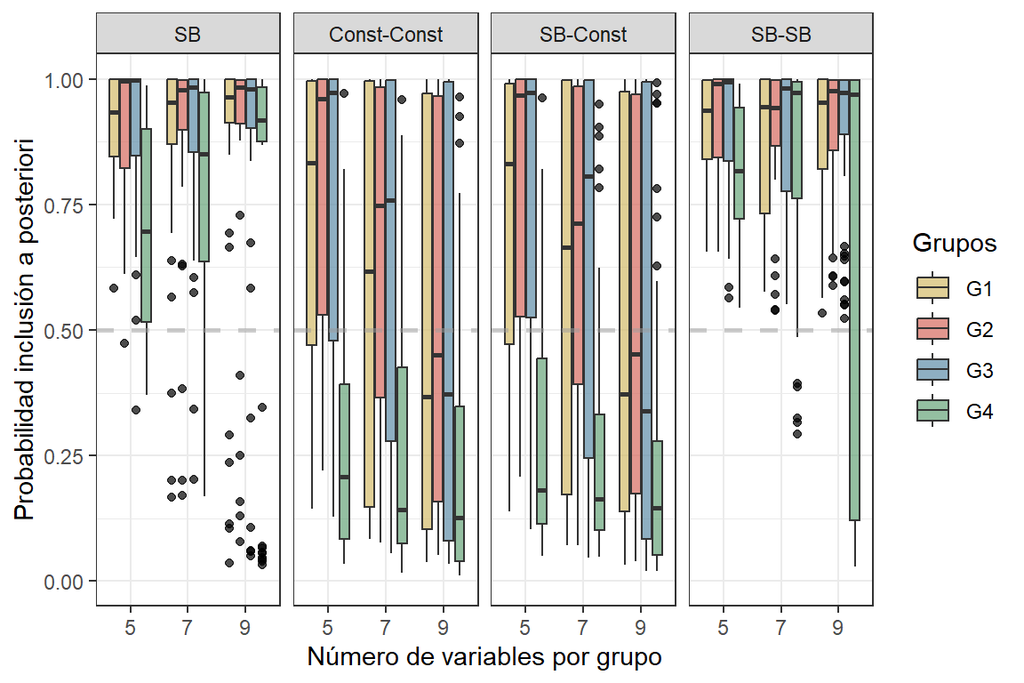

En función del número de variables:

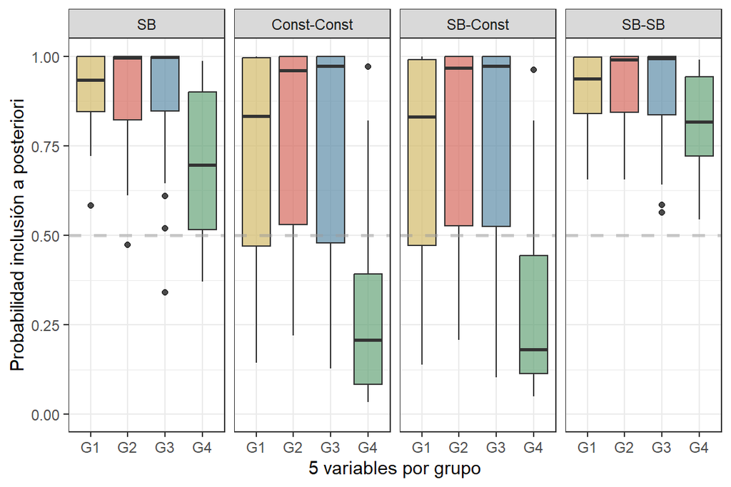

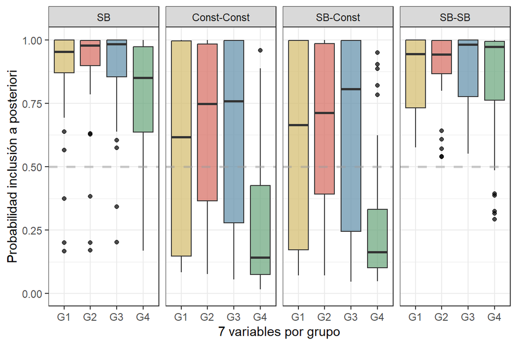

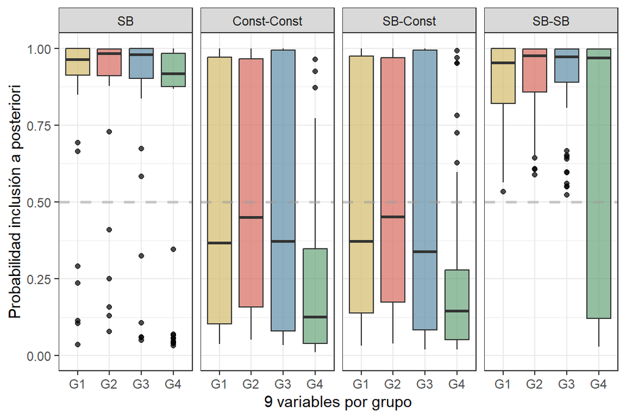

Porcentaje de variables agrupadas incorrectamente no seleccionados:

Porcentaje de variables agrupadas incorrectamente no seleccionadas para SB.

|  | G1 | G2 | G3 |
| --- | --- | --- | --- |
| Num vars = 5 | 0% | 4% | 4% |
| Num vars = 7 | 8.57142857142857% | 8.57142857142857% | 5.71428571428571% |
| Num vars = 9 | 11.1111111111111% | 11.1111111111111% | 11.1111111111111% |

Porcentaje de variables agrupadas incorrectamente no seleccionadas para Const-Const.

|  | G1 | G2 | G3 |
| --- | --- | --- | --- |
| Num vars = 5 | 28% | 24% | 28% |
| Num vars = 7 | 42.8571428571429% | 31.4285714285714% | 45.7142857142857% |
| Num vars = 9 | 51.1111111111111% | 53.3333333333333% | 53.3333333333333% |

Porcentaje de variables agrupadas incorrectamente no seleccionadas para SB-Const.

|  | G1 | G2 | G3 |
| --- | --- | --- | --- |
| Num vars = 5 | 28% | 24% | 24% |
| Num vars = 7 | 42.8571428571429% | 28.5714285714286% | 45.7142857142857% |
| Num vars = 9 | 51.1111111111111% | 53.3333333333333% | 53.3333333333333% |

Porcentaje de variables agrupadas incorrectamente no seleccionadas para SB-SB.

|  | G1 | G2 | G3 |
| --- | --- | --- | --- |
| Num vars = 5 | 0% | 0% | 0% |
| Num vars = 7 | 0% | 0% | 0% |
| Num vars = 9 | 0% | 0% | 0% |

Porcentaje de variables agrupadas incorrectamente seleccionados:

Porcentaje de variables agrupadas incorrectamente seleccionadas para SB.

|  | G4 |
| --- | --- |
| Num vars = 5 | 76% |
| Num vars = 7 | 80% |
| Num vars = 9 | 80% |

Porcentaje de variables agrupadas incorrectamente seleccionadas para Const-Const.

|  | G4 |
| --- | --- |
| Num vars = 5 | 20% |
| Num vars = 7 | 22.8571428571429% |
| Num vars = 9 | 17.7777777777778% |

Porcentaje de variables agrupadas incorrectamente seleccionadas para SB-Const.

[output not shown]

Porcentaje de variables agrupadas incorrectamente seleccionadas para SB-SB.

[output not shown]